# Лекция 05. Библиотека NumPy

Постановка задачи и повторение темы "списки и словари"

## Оглавление:

- 05.01. Постановка задачи
- 05.02. Описание библиотеки
  - Измерение массива
  - Доступ к массиву
  - Другие операции с массивом
  - Измерение массива
  - Измерение массива
  - Измерение массива
  - Измерение массива
- 05.02. Numpy и матричная алгебра
- 05.03. Скалярное произведение векторов
- 05.04. Перемножение матриц
- 05.05. Домашнее задание

### Постановка задачи и повторение темы "списки и словари"

Есть статистика с сайта http://www.bodycounters.com

- Дана статистика погибших в серии фильмов "Пираты Карибского моря".
- Посчитайте среднее число погибших людей в каждом фильме.
- Пиратов зомби за людей не считайте.

```python
stats = [
    {
        'movie': 'На странных берегах',
        'bodycount': {'люди': 56, 'русалки': 2, 'ядовитые жабы': 3, 'пираты-зомби': 2}
    },
    {
        'movie': 'На краю света',
        'bodycount': {'люди': 88}
    },
    {
        'movie': 'Сундук мертвеца',
        'bodycount': {'люди': 56, 'крабы отшельники': 1}
    },
    {
        'movie': 'Проклятие Черной жемчужины',
        'bodycount': {'люди': 17}
    },
]
```

Что можно сделать:

1. Пройтись по списку stats
2. В каждом элементе взять словарь по ключу 'bodycount'
3. В словаре по ключу 'bodycount' взять значение ключа 'люди'
4. Просуммировать количество людей во всех шагах
5. Поделить сумму людей на количество фильмов

```python
# Повторим обращение к список из словарей
# stats[0] # Первый элемент
# stats[0]['bodycount'] # Значения к ключу
# stats[0]['movie'] # Значения к ключу
stats[0]['bodycount']['люди'] # Значения по ключу + вытасчкиваем значение люди
```

```
56
```

```python
body_count = 0
for record in stats:
    body_count += record['bodycount']['люди']
print(f"В среднем погибло людей: {body_count / len(stats)} за фильм")
```

```
В среднем погибло людей: 54.25 за фильм
```

# Описание библиотеки Numpy

Библиотека для работы с многомерными массивами. Используется в анализе данных и обучении нейронных сетей

Массивы в NumPy отличаются от обычных списков и кортежей в Python тем, что они должны состоять только из элементов одного типа. Такое ограничение позволяет увеличить скорость вычислений в 50 раз, а также избежать ненужных ошибок с приведением и обработкой типов.

Главный объект библиотеки NumPy — массив. Создаётся он очень просто:

```python
import numpy as np
```

```python
a1 = np.array([1, 2, 3]) # Одномерный
a2 = np.array([[1, 2, 3], [4, 5, 6]]) # Двумерный из двух одномерных
a3 = np.array([[[1, 2, 3], [4, 5, 6]], [[7, 8, 9], [10, 11, 12]]]) # Трехмерный из двух двумерных

print (a1);
print (a2);
print (a3);
```

```
[1 2 3]
[[1 2 3]
 [4 5 6]]
[[[ 1  2  3]
  [ 4  5  6]]

 [[ 7  8  9]
  [10 11 12]]]
```

Так можно продолжать:

- четырёхмерный массив состоит из трёхмерных;
- пятимерный массив — это несколько четырёхмерных;
- n-мерный массив — это несколько (n-1)-мерных.

Пример черырехмерного массива:

[figure not shown]

### Измерение массива

```python
# Допустим, у нас есть такой объект:
a = np.array([1,2,3], dtype='int32')
print(a)
```

```
[1 2 3]
```

```python
# Узнать, сколько у него измерений
print(a.ndim) # Одномерный массив
print(a2.ndim) # Двумерный массив
```

```
1
2
```

```python
# Посчитать количество строк и столбцов
print(a.shape) # Одномерный массив, вектор из 3 элементов
print(a2.shape) # Двумерный массив, 2 строки и 3 столбца
print(a3.shape) # Трехмерный массив, 2 двухмерных массива с 2 строками и 3 столбцами
```

```
(3,)
(2, 3)
(2, 2, 3)
```

```python
# Узнать тип элементов
print(a.dtype)
```

```
int32
```

```python
# Узнать кол-во элементов
print(a.size)
```

```
3
```

### Доступ к массиву

В NumPy можно обращаться к отдельным элементам, строкам или столбцам, а также точечно выбирать последовательность нужных элементов.

Допустим, у нас есть двумерный массив:

```python
a = np.array([[1, 2, 3, 4, 5, 6, 7], [8, 9, 10, 11, 12, 13, 14]])
print(a)
```

```
[[ 1  2  3  4  5  6  7]
 [ 8  9 10 11 12 13 14]]
```

```python
print(a[0, 4]) # Элемент в 1 строке и 5 столбце. Нумерация с 0
```

```
5
```

```python
c = np.array([[[1, 2, 3], [4, 5, 6]], [[7, 8, 9], [10, 11, 12]]])
print(c)
print(c[1, 1, 1])# Элемент во 2 таблице во 2 строке в 2 столбце
```

```
[[[ 1  2  3]
  [ 4  5  6]]

 [[ 7  8  9]
  [10 11 12]]]
11
```

```python
# Можно обратиться к целой строке:
print(a[0, :])
# Можно обратиться к целому столбцу:
print(a[:, 0])
```

```
[1 2 3 4 5 6 7]
[1 8]
```

```python
# В целом конструкция выглядит, как начальный_индекс: конечный_индекс: шаг
b = np.array([[1, 2, 3, 4], [5, 6, 7, 8]])
print(b[0, 1:4:2]) # Берем значение из 1 таблицы, со второго значения до последнего с шагом 2
```

```
[2 4]
```

```python
# Можно менять последовательности:
c = np.array([[0, 2], [4, 6]])
c[0, :] = [3, 3] # Заменили 1 ую строку
print(c)
```

```
[[3 3]
 [4 6]]
```

### Изменение массива

**Копирование массива**

NumPy-массивы нельзя просто присвоить другой переменной, чтобы скопировать.  
Если в NumPy вы присвоите массив другой переменной, то просто создадите ссылку на него.

Для этого существует функция **copy**.  
Изменение структуры данных - **reshape**, **vstack** и **hstack*

```python
# Допустим, есть массив
a = np.array([1, 2, 3])
# Копируем через присвоение новой переменной
b = a
# Меняем элемент
b[0] = 5
# Сравниваем результат:
print(b)
print(a)

# b поменялся вместе с a.
# Причина - массивы в NumPy - это только ссылки на области в памяти.
```

```
[5 2 3]
[5 2 3]
```

```python
# Тот же пример,  но уже с копированием
a = np.array([1, 2, 3])
# Копируем правильно
b = a.copy()
# Меняем элемент
b[0] = 5
# Сравниваем результат:
print(b)
print(a)
```

```
[5 2 3]
[1 2 3]
```

**Изменение размера массива**

Так же можно менять размер массива, склеивать 2 разных массива

```python
# Ещё мы можем менять размер массива с помощью функции reshape:

a = np.array([[1, 2, 3, 4], [5, 6, 7, 8]])
print(a)
b = a.reshape((4, 2))

print(b)
# Заметьте: новые размеры должны соответствовать количеству элементов
```

```
[[1 2 3 4]
 [5 6 7 8]]
[[1 2]
 [3 4]
 [5 6]
 [7 8]]
```

```python
# Ещё NumPy позволяет нам «наслаивать» массивы друг на друга и соединять их с помощью функций vstack и hstack:
v1 = np.array([1, 2, 3])
v2 = np.array([9, 8, 7])
v3 = np.vstack([v1, v2])

print(v3)
# Создали двумерный массив из двух векторов одинакового размера, которые «поставили» друг на друга.
```

```
[[1 2 3]
 [9 8 7]]
```

```python
h1 = np.ones((2, 4))
h2 = np.zeros((2, 2))
h3 = np.hstack((h1, h2))

print(h3)

# К массиву из единиц справа присоединился массив из нулей.
```

```
[[1. 1. 1. 1. 0. 0.]
 [1. 1. 1. 1. 0. 0.]]
```

**Добавление элементов в массив**

```python
?np.append()
```

```python
print(np.append(a,'august'))
print(a) # Вернулась, как было
a = np.append(a,'august') # Надо переназначать объект/ присваивать его заново после операций, чтобы он обновился.
print(a)
```

```
['1' '2' '3' '4' '5' '6' '7' '8' 'august']
[[1 2 3 4]
 [5 6 7 8]]
['1' '2' '3' '4' '5' '6' '7' '8' 'august']
```

### Другие операции с массивом

**Argmax/argmin - Поиск индекса минимального и максимального значений**

```python
x = np.array(list(range(0,11)))
print(x)
print(type(x))
```

```
[ 0  1  2  3  4  5  6  7  8  9 10]
<class 'numpy.ndarray'>
```

```python
print(x.argmax())
print(x.argmin())
```

```
10
0
```

```python
x[5] = 99
x[9] = -99
x
```

```
array([  0,   1,   2,   3,   4,  99,   6,   7,   8, -99,  10])
```

```python
print(x.argmax()) # Показывает индекс максимального значения, бывает очень полезно при поиске значений в массиве
print(x.argmin()) # Показывает индекс минимального значения
```

```
5
9
```

**Unique -**

```python
np.unique(a)
```

```
array(['1', '2', '3', '4', '5', '6', '7', '8', 'august'], dtype='<U11')
```

```python
b = np.unique(a)
b
```

```
array(['1', '2', '3', '4', '5', '6', '7', '8', 'august'], dtype='<U11')
```

```python
a
```

```
array(['1', '2', '3', '4', '5', '6', '7', '8', 'august'], dtype='<U11')
```

**Concatenate**

```python
spring = np.array(['march', 'april', 'may'])
summer = np.array(['june', 'july', 'august'])
warm_months = np.concatenate([spring, summer])
warm_months
```

```
array(['march', 'april', 'may', 'june', 'july', 'august'], dtype='<U6')
```

**Пересечение двух массивов**

```python
# Нередко стоит задача найти общие объекты среди 2-х массивов и найти общие элементы.
a = np.array([1,10,100,1000])
b = np.array([1,4,100])
# А теперь пересечем их методом np.intersect1d() и передадим 2 вектора в качестве аргументов.
c = np.intersect1d(a, b)
c
```

```
array([  1, 100])
```

```python
# Этот метод, конечно, работает не только с цифрами, но и с другими объектами, например с строками.
a = np.array(['Юля', 'Олег', 'Роман', 'Иван'])
b = np.array(['Юля','Иван','Леонид'])
c = np.intersect1d(a,b)
c
```

```
array(['Иван', 'Юля'], dtype='<U6')
```

```python
(a, b)
```

```
(array(['Юля', 'Олег', 'Роман', 'Иван'], dtype='<U5'),
 array(['Юля', 'Иван', 'Леонид'], dtype='<U6'))
```

Более жизненный пример.

На "игрушечном" ималеньком массиве мы смогли построить пересечение. Принцип остается тот же, если мы ,например, хотим найти пересечение между большим количеством объектов. Допустим у нас есть какие-либо id пользователей и нам нужно найти пересечение между группами.

```python
import random
import time

%time
customer_ids_a = random.sample(range(1000000, 5000000), 1000000)
customer_ids_b = random.sample(range(1000000, 5000000), 1000000)
```

```
Wall time: 0 ns
```

```python
# Посмотрим на наши массивы, делая срезы в 5 и 10 элементов.
print('Массив А:%s'%customer_ids_a[:5])
print('Массив Б:%s'%customer_ids_b[:10])
```

```
Массив А:[1660323, 3377891, 4131911, 1323706, 2372919]
Массив Б:[2306325, 2280549, 2131279, 4799620, 2892836, 4839805, 4170319, 4386735, 2872150, 4961578]
```

В таких задачах так же могут попадаться неуникальные или повторяющиеся значения, которые не хотелось бы использовать, чтобы избежать ошибок и коллизий. Вспомним упомянутый выше удобный метод .unique(), который возвращает нам только уникальные значения обхекта к которому мы его применям. Проверим наши вектора на уникальность.

```python
print('Уникальныых значений в массиве А: %s'% len(np.unique(customer_ids_a)))
print('Уникальныых значений в массиве Б: %s'% len(np.unique(customer_ids_b)))
```

```
Уникальныых значений в массиве А: 1000000
Уникальныых значений в массиве Б: 1000000
```

Все проверив, мы можем применить метод .intersect1d() и посмотреть на пересечение.

```python
%time
c = np.intersect1d(customer_ids_a,customer_ids_b)
```

```
Wall time: 0 ns
```

```python
c
```

```
array([1000014, 1000023, 1000076, ..., 4999923, 4999969, 4999986])
```

Так как у нас довольно большое количество элементов в списке, то веротяность того что будет хотя бы одно пересечение довольно высока. Посмотрим на то, что у нас получилось.

У нас получился вектор пересечений, который не вмещается строчку отображения в Jupyter notebook, так что давайте посмотрим на то сколько у нас получилось в нем объектов, используя метод len().

```python
print('Наше пересечение равно %s объектам.' %len(c))
```

```
Наше пересечение равно 249724 объектам.
```

В 1 строчкe можно посчитать отношение нашего пересечения к количеству id нашего массива, в котором мы искали пересечение.

```python
len(c)/len(customer_ids_b)*100
```

```
24.9724
```

И предстваить его в более читаемом и осмысленном виде.

```python
print('Наше пересечение равно %s процентов.'%round(len(c)/len(customer_ids_b)*100,2))
```

```
Наше пересечение равно 24.97 процентов.
```

Другие методы для выполнения математических и логических операций с векторами и матрицами можно найти в документации на официальном сайте [библиотеки](https://docs.scipy.org/doc/numpy-1.15.1/reference/).

# Numpy и матричная алгебра

```python
import numpy as np
```

```python
x = np.array( [1, 2, 3] )
y = np.array( [4, 5, 6] )
```

```python
type(x)
```

```
numpy.ndarray
```

```python
type([1, 2, 3])
```

```
list
```

```python
# дополнительные методы
x.mean()
```

```
2.0
```

### Поэлементные операции

```python
x + y
```

```
array([5, 7, 9])
```

```python
x * y
```

```
array([ 4, 10, 18])
```

```python
x - y
```

```
array([-3, -3, -3])
```

```python
x / y
```

```
array([0.25, 0.4 , 0.5 ])
```

```python
x, y
```

```
(array([1, 2, 3]), array([4, 5, 6]))
```

```python
# элементы массива x возводятся в соответствующие степени элементов массива y
x ** y
```

```
array([  1,  32, 729], dtype=int32)
```

```python
# остаток от деления
# обратите внимание, что для удобства данного примера x и y идут в другом порядке

y % x
```

```
array([0, 1, 0], dtype=int32)
```

### Автоматическое наполнение массивов

```python
# аналог range

np.arange(0, 10)
```

```
array([0, 1, 2, 3, 4, 5, 6, 7, 8, 9])
```

```python
# создать массив из 10 чисел, заполненных единицами
np.full(10, 1)
```

```
array([1, 1, 1, 1, 1, 1, 1, 1, 1, 1])
```

```python
# создать матрицу 2х5 из нулей
np.full([2, 5], 0)
```

```
array([[0, 0, 0, 0, 0],
       [0, 0, 0, 0, 0]])
```

```python
# объединить массивы в один
a = np.arange(10)
b = np.arange(10, 20)

# обратите внимание на двойные скобки
np.concatenate((a, b))
```

```
array([ 0,  1,  2,  3,  4,  5,  6,  7,  8,  9, 10, 11, 12, 13, 14, 15, 16,
       17, 18, 19])
```

```python
# перемешать элементы массива
import random

nums = np.arange(10)
random.shuffle(nums)

nums
```

```
array([0, 3, 6, 2, 7, 4, 1, 8, 5, 9])
```

### Упражнение

По мотивам https://thecode.media/choose-life/

По результатам собеседования вам предлагают определенную зарплату. И конверт, который может случайным образом снизить или увеличить эту зарплату вдвое. Т. е. если сначала была сумма Х, то после вскрытия конверта она может стать 0.5Х или 2Х. Как в среднем изменится будущая зарплата, если соискатель решил открыть конверт?

Смоделируйте процесс изменения условной зарплаты в 1000 в случае открытия конверта:

1. Задайте переменную n_samples = 1000
2. Создайте numpy array из n_samples элементов, равных зарплате 0.5Х. И такой же с зарплатой 2Х.
3. Объедините их в один массив
4. Перемешайте значения в получившемся массиве
5. Посчитайте среднее значение зарплаты для объединенного массива

```python
import random
n_samples = 1000
X = 100
n_05X = np.full(n_samples, 0.5 * X)
n_20X = np.full(n_samples, 2.0 * X)
n_shuff = np.concatenate((n_05X, n_20X))
random.shuffle(n_shuff)
n_shuff.mean()
```

```
125.0
```

```python
import random
n_samples = 1000
X = 100
n_05X = np.full(n_samples, 0.5 * n_samples)
n_20X = np.full(n_samples, 2.0 * n_samples)
n_shuff = np.concatenate((n_05X, n_20X))
random.shuffle(n_shuff)
n_shuff.mean()
```

```
1250.0
```

### Изменение размерности

```python
x = np.arange( 0, 10 )
x
```

```
array([0, 1, 2, 3, 4, 5, 6, 7, 8, 9])
```

```python
# 10 - количество строк

x.shape
```

```
(10,)
```

```python
np.array(
    [
        [1, 2],
        [3, 4],
        [5, 6]
    ]
).shape
```

```
(3, 2)
```

```python
# первый аргумент - количество строк
# второй - столбцов

x.reshape( 5, 2 )
```

```
array([[0, 1],
       [2, 3],
       [4, 5],
       [6, 7],
       [8, 9]])
```

```python
x.reshape( 3, 3 )
```

```
---------------------------------------------------------------------------
ValueError                                Traceback (most recent call last)
<ipython-input-32-6216b950ff5f> in <module>()
----> 1 x.reshape( 3, 3 )

ValueError: cannot reshape array of size 10 into shape (3,3)
```

```python
# транспонирование матриц

np.array(
    [
        [1, 2],
        [3, 4],
        [5, 6]
    ]
).T
```

```
array([[1, 3, 5],
       [2, 4, 6]])
```

```python
# склеивание набора списков
[1, 2, 3] + [4, 5, 6]
```

```
[1, 2, 3, 4, 5, 6]
```

```python
# склеивание массива из списков

x = np.array( [ [1, 2, 3], [4, 5, 6] ] )
x.ravel()
```

```
array([1, 2, 3, 4, 5, 6])
```

```python
# можно и так

x.reshape( 6 )
```

```
array([1, 2, 3, 4, 5, 6])
```

```python
# результат разный, если добавить 1 в качестве количества строк

x.reshape( 1, 6 )
```

```
array([[1, 2, 3, 4, 5, 6]])
```

### Создание матриц

```python
# нулевой вектор заданной размерности

np.zeros(10)
```

```
array([0., 0., 0., 0., 0., 0., 0., 0., 0., 0.])
```

```python
# единичная матрица

np.eye(5)
```

```
array([[1., 0., 0., 0., 0.],
       [0., 1., 0., 0., 0.],
       [0., 0., 1., 0., 0.],
       [0., 0., 0., 1., 0.],
       [0., 0., 0., 0., 1.]])
```

```python
# более общий случай диагональной матрицы

np.diag(np.arange(5), k=0)
```

```
array([[0, 0, 0, 0, 0],
       [0, 1, 0, 0, 0],
       [0, 0, 2, 0, 0],
       [0, 0, 0, 3, 0],
       [0, 0, 0, 0, 4]])
```

```python
np.diag(np.arange(5), k=-2)
```

```
array([[0, 0, 0, 0, 0, 0, 0],
       [0, 0, 0, 0, 0, 0, 0],
       [0, 0, 0, 0, 0, 0, 0],
       [0, 1, 0, 0, 0, 0, 0],
       [0, 0, 2, 0, 0, 0, 0],
       [0, 0, 0, 3, 0, 0, 0],
       [0, 0, 0, 0, 4, 0, 0]])
```

```python
# матрица со случайными значениями

np.random.random(10)
```

```
array([0.45367103, 0.82049307, 0.58658308, 0.81845576, 0.05024765,
       0.55612661, 0.2904897 , 0.70603553, 0.76295571, 0.85882816])
```

```python
# более универсальный вариант создания матриц

?np.linspace
```

```python
np.linspace(5, 25, 30)
```

```
array([ 5.        ,  5.68965517,  6.37931034,  7.06896552,  7.75862069,
        8.44827586,  9.13793103,  9.82758621, 10.51724138, 11.20689655,
       11.89655172, 12.5862069 , 13.27586207, 13.96551724, 14.65517241,
       15.34482759, 16.03448276, 16.72413793, 17.4137931 , 18.10344828,
       18.79310345, 19.48275862, 20.17241379, 20.86206897, 21.55172414,
       22.24137931, 22.93103448, 23.62068966, 24.31034483, 25.        ])
```

### Более сложные распределения

https://docs.scipy.org/doc/scipy-0.14.0/reference/generated/scipy.signal.gaussian.html

### Упражнение

Дана единичная матрица np.eye(10). Посчитайте сумму ее диагональных элементов.

```python
# один из вариантов подсчета суммы
# он не является самым простым или самым сложным

total_sum = 0

for element in len(np.eye(10)):
    print(element[element][element])
# total_sum += element

total_sum
```

```
---------------------------------------------------------------------------
TypeError                                 Traceback (most recent call last)
<ipython-input-58-15294e756e04> in <module>()
      4 total_sum = 0
      5
----> 6 for element in len(np.eye(10)):
      7     print(element[element][element])
      8 # total_sum += element

TypeError: 'int' object is not iterable
```

```python
total_sum = 0
a=np.eye(10)
for i in range(len(a)):
    total_sum+=a[i][i]
print(total_sum)
```

```
10.0
```

Рассмотрим, зачем нужны операции с матрицами на практике:

- Допустим, есть фильмы, которые можно определить параметрами, их можно превратить в цифры, которые можно представить в виде вектора
- Т.е. мы можем брать различные данные, к примеру товары и посчитать угол между этими векторами
- Если угол близок к нулю, то объекты близки, если к 90 градусам то нет
- Для решения взяли косинусное расстояние: т.к. оно при 0 градусов = 1, и при 90 градусах = 0 (Чем больше к.р., тем больше)

Для того, что бы посчитать используется скалярное произведение векторов:

# Скалярное произведение векторов

\begin{equation*} \LARGE \vec{a} \dot{} \vec{b} = |\vec{a}| \space |\vec{b}| \space cos(\vec{a}, \vec{b}) \end{equation*}

Пусть \begin{equation*} \LARGE \vec{a} = (a_1, a_2, a_3) \\ \LARGE \vec{b} = (b_1, b_2, b_3) \end{equation*}

Тогда скалярное произведение векторов равно \begin{equation*} \LARGE \vec{a} \dot{} \vec{b} = a_1 b_1 + a_2 b_2 + a_3 b_3 \end{equation*}

```python
a = np.array( [4, 3] )
b = np.array( [2, 1] )
```

```python
4 * 2 + 3 * 1
```

```
11
```

Пример расчета скалярного произведения векторов

```python
np.dot( a, b ) # метод для тоже самого
```

```
11
```

Можно посчитать и таким образом

```python
# первый шаг

for pair in zip( a, b ):
    print( pair )
```

```
(4, 2)
(3, 1)
```

```python
# второй шаг

[ pair[0] * pair[1] for pair in zip( a, b ) ]
```

```
[8, 3]
```

```python
# итоговый результат

sum( [ pair[0] * pair[1] for pair in zip( a, b ) ] )
```

```
11
```

# Косинусное расстояние между векторами

\begin{equation*} \LARGE cos(\vec{a}, \vec{b}) = \frac{\vec{a} \dot{} \vec{b}}{|\vec{a}| \space |\vec{b}|} \end{equation*}

```python
import matplotlib.pyplot as plt # произведение модуля векторов
```

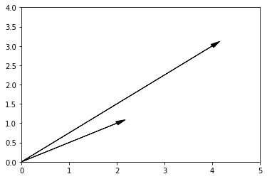

```python
ax = plt.axes()

plt.xlim( [0, 5] )
plt.ylim( [0, 4] )

ax.arrow( 0, 0, a[0], a[1], head_width=0.1, head_length=0.2, fc='k', ec='k' )
ax.arrow( 0, 0, b[0], b[1], head_width=0.1, head_length=0.2, fc='k', ec='k' )

plt.show()
```

```python
def cosine( a, b ):
    """
    Подсчет косинуса угла между векторами a, b по их координатам
    """

    # длины векторов
    aLength = np.linalg.norm( a )
    bLength = np.linalg.norm( b )

    return np.dot( a, b ) / ( aLength * bLength )
```

```python
# длины векторов можно было посчитать и так

aLength = np.sqrt( (a*a).sum() )
bLength = np.sqrt( (b*b).sum() )
```

```python
cosine( a, b )
```

```
0.9838699100999074
```

```python
# угол между векторами в радианах

np.arccos( cosine( a, b ) )
```

```
0.17985349979247847
```

```python
# угол между векторами в градусах

np.arccos( cosine( a, b ) ) * 360 / 2 / np.pi
```

```
10.304846468766044
```

## Упражнение

Имеется матрица покупок в интернет-магазине. Столбец А - ID пользователя. Остальные столбцы - количество покупок категорий товаров этим пользователем:

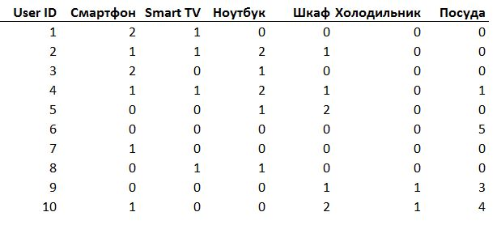

```python
from IPython.display import Image
Image("user_matrix.JPG")
```

Матрица в виде numpy array

```python
users_stats = np.array(
    [
        [2, 1, 0, 0, 0, 0],
        [1, 1, 2, 1, 0, 0],
        [2, 0, 1, 0, 0, 0],
        [1, 1, 2, 1, 0, 1],
        [0, 0, 1, 2, 0, 0],
        [0, 0, 0, 0, 0, 5],
        [1, 0, 0, 0, 0, 0],
        [0, 1, 1, 0, 0, 0],
        [0, 0, 0, 1, 1, 3],
        [1, 0, 0, 2, 1, 4]
    ],
    np.int32
)
```

На сайт заходит очередной посетитель, о покупках которого известно следующее:

```python
next_user_stats = np.array([0, 1, 2, 0, 0, 0])
```

Найдите самого похожего пользователя. Т. е. посчитайте косинусное расстояние между этим пользователем и всеми пользователями из массива user_stats

```python
# по сути нужно найти скалярное произведение между векторами каждого вектора
```

```python
cnt = 0
for i in users_stats:
    res = cosine( i, next_user_stats )
    print(res)
```

```
0.19999999999999996
0.8451542547285165
0.3999999999999999
0.7905694150420948
0.3999999999999999
0.0
0.0
0.9486832980505138
0.0
0.0
```

```python
result = 1
counter = 1
temp = 0
for row in users_stats:
    cos = cosine(next_user_stats, row )
    if cos > temp:
        temp = cos
        result = counter
    counter += 1
print(result)
```

```
8
```

```python
a = np.array( [4, 3] )
b = np.array( [2, 1] )
```

```python
a = users_stats[1]
b = next_user_stats
np.dot( a, b )
```

```
5
```

```python
def cosine( a, b ):
    """
    Подсчет косинуса угла между векторами a, b по их координатам
    """

    # длины векторов
    aLength = np.linalg.norm( a )
    bLength = np.linalg.norm( b )

    return np.dot( a, b ) / ( aLength * bLength )
```

```python
cosine( a, b )
```

```
0.8451542547285165
```

```python
next_user_stats = np.array([0, 1, 2, 0, 0, 0])
cos_max=0
ind=-1
for i in range(len(users_stats)):
    if(cosine( next_user_stats,users_stats[i] )>cos_max):
        cos_max=cosine( next_user_stats,users_stats[i] )
        ind=i
print(ind)
```

```
7
```

# Перемножение матриц

**Определение**

Пусть даны две матрицы a и b размером l x m и m x n соответственно. l - количество строк, n - количество столбцов.

\begin{equation*} \LARGE a = \begin{bmatrix} a_{11} & a_{12} \dots a_{1m} \\ a_{21} & a_{22} \dots a_{2m} \\ \vdots & \vdots \dots \vdots \\ a_{l1} & a_{l2} \dots a_{lm} \end{bmatrix} \end{equation*}

\begin{equation*} \LARGE b = \begin{bmatrix} b_{11} & b_{12} \dots b_{1n} \\ b_{21} & b_{22} \dots b_{2n} \\ \vdots & \vdots \dots \vdots \\ b_{m1} & b_{m2} \dots b_{mn} \end{bmatrix} \end{equation*}

Тогда произведением матриц a и b будет матрица c размерностью l x n:

\begin{equation*} \LARGE c = \begin{bmatrix} c_{11} & c_{12} \dots c_{1n} \\ c_{21} & c_{22} \dots c_{2n} \\ \vdots & \vdots \dots \vdots \\ c_{l1} & c_{l2} \dots c_{ln} \end{bmatrix} \end{equation*}

\begin{equation*} \LARGE c_{ij} = \sum_{k=1}^m a_{ik} b_{kj} \end{equation*}

```python
a = np.array(
    [
        [1, 2],
        [3, 4]
    ]
)
```

```python
b = np.array(
    [
        [5, 6],
        [7, 8]
    ]
)
```

```python
c11 = 1 * 5 + 2 * 7
c11
```

```
19
```

```python
c12 = 1 * 6 + 2 * 8
c12
```

```
22
```

```python
c = np.dot( a, b )
c
```

```
array([[19, 22],
       [43, 50]])
```

В numpy есть специальный тип matrix, который отличается от ndarray

```python
aMatrix = np.matrix( [ [1, 2], [3, 4] ] )
bMatrix = np.matrix( [ [5, 6], [7, 8] ] )
```

```python
type(aMatrix)
```

```
numpy.matrixlib.defmatrix.matrix
```

```python
aMatrix * bMatrix
```

```
matrix([[19, 22],
        [43, 50]])
```

```python
a * b # если перемножить 2 массива в numpy - поэлементно
```

```
array([[ 5, 12],
       [21, 32]])
```

```python
type( aMatrix ), type( a )
```

```
(numpy.matrixlib.defmatrix.matrix, numpy.ndarray)
```

```python
np.mat( a ) * np.mat( b )
```

```
matrix([[19, 22],
        [43, 50]])
```

# Линейные уравнения

Дана система линейных уравнений

\begin{equation*} \LARGE x + 3*y = 9 \\ \LARGE 2*x - 4*y = 8 \end{equation*}

```python
# коэффициенты при переменных в левой части уравнения

a = np.array( [ [1, 3], [2, -4] ] )
```

```python
# значения в правой части уравнения

b = np.array( [9, 8] )
```

```python
# решение

from numpy import linalg
```

```python
linalg.solve(a, b)
```

```
array([6., 1.])
```

```python
# проверка верности решения уравнения

np.allclose( np.dot(a, linalg.solve(a, b)), b )
```

```
True
```

# Домашнее задание

Задание 1

Создайте numpy array с элементами от числа N до 0 (например, для N = 10 это будет array([9, 8, 7, 6, 5, 4, 3, 2, 1, 0])).

```python
import numpy as np
N = 10
np.arange(N-1, -1, -1)
```

```
array([9, 8, 7, 6, 5, 4, 3, 2, 1, 0])
```

Задание 2

Создайте диагональную матрицу с элементами от N до 0. Посчитайте сумму ее значений на диагонали.

```python
N = 10
a = np.diag(np.arange(N-1, -1, -1), k=0)
a # выводим матрицу
```

```
array([[9, 0, 0, 0, 0, 0, 0, 0, 0, 0],
       [0, 8, 0, 0, 0, 0, 0, 0, 0, 0],
       [0, 0, 7, 0, 0, 0, 0, 0, 0, 0],
       [0, 0, 0, 6, 0, 0, 0, 0, 0, 0],
       [0, 0, 0, 0, 5, 0, 0, 0, 0, 0],
       [0, 0, 0, 0, 0, 4, 0, 0, 0, 0],
       [0, 0, 0, 0, 0, 0, 3, 0, 0, 0],
       [0, 0, 0, 0, 0, 0, 0, 2, 0, 0],
       [0, 0, 0, 0, 0, 0, 0, 0, 1, 0],
       [0, 0, 0, 0, 0, 0, 0, 0, 0, 0]])
```

```python
# Считаем сумму значений на диагонали
total_sum = 0
for i in range(len(a)):
    total_sum+=a[i][i]
print(total_sum)
```

```
45
```

Задание 3. Решите систему уравнений:

\begin{equation*} \LARGE 4*x + 2*y + z = 4 \\ \LARGE x + 3*y = 12 \\ \LARGE 5*y + 4*z = -3 \end{equation*}

```python
left = np.array([[4, 2, 1], [1, 3, 0], [0, 5, 4]]) # левая часть уравнения
right = np.array( [4, 12, -3] ) # правая часть уравнения
from numpy import linalg
# решение уравнения
linalg.solve(left, right)
```

```
array([ 0.46666667,  3.84444444, -5.55555556])
```

```python
# проверка верности решения уравнения
np.allclose( np.dot(left, linalg.solve(left, right)), right )
```

```
True
```